# Regression multiple

Arthur Zucker

11/29/2019

# Introduction

Nous allons utiliser la base de données ozone vu au TP précedent.

```
##        RC                LT              HF              PR
##  Min.   :  1.000   Min.   :25.00   Min.   : 30.0   Min.   :  38.0
##  1st Qu.:  3.004   1st Qu.:50.00   1st Qu.: 70.0   1st Qu.: 250.0
##  Median : 11.023   Median :60.00   Median : 85.0   Median : 795.0
##  Mean   : 28.527   Mean   :62.55   Mean   :123.2   Mean   : 696.8
##  3rd Qu.: 31.507   3rd Qu.:75.00   3rd Qu.:165.0   3rd Qu.:1020.0
##  Max.   :221.406   Max.   :95.00   Max.   :305.0   Max.   :1618.0
##        PA               FE
##  Min.   :  23.0   Min.   :1.0
##  1st Qu.: 123.0   1st Qu.:3.5
##  Median : 529.0   Median :5.0
##  Mean   : 718.6   Mean   :5.0
##  3rd Qu.: 800.0   3rd Qu.:6.0
##  Max.   :3273.0   Max.   :8.0
```

```r
res = lm(RC ~ .,data)
summary(res)
```

```
##
## Call:
## lm(formula = RC ~ ., data = data)
##
## Residuals:
##     Min      1Q  Median      3Q     Max
## -56.525 -10.246   3.087   6.867  99.393
##
## Coefficients:
##              Estimate Std. Error t value Pr(>|t|)
## (Intercept) -0.817509  22.183305  -0.037   0.9709
## LT          -0.340660   0.430803  -0.791   0.4365
## HF           0.167142   0.114052   1.465   0.1553
## PR           0.085712   0.031552   2.716   0.0118 *
## PA          -0.008825   0.007345  -1.201   0.2408
## FE          -4.665758   4.007717  -1.164   0.2553
## ---
## Signif. codes:  0 '***' 0.001 '**' 0.01 '*' 0.05 '.' 0.1 ' ' 1
##
## Residual standard error: 27.56 on 25 degrees of freedom
## Multiple R-squared:  0.6707, Adjusted R-squared:  0.6048
## F-statistic: 10.18 on 5 and 25 DF,  p-value: 2.075e-05
```

```r
anova(res)
```

```
## Analysis of Variance Table
##
## Response: RC
##           Df  Sum Sq Mean Sq F value    Pr(>F)
## LT         1  9603.6  9603.6 12.6412  0.001536 **
## HF         1 23400.9 23400.9 30.8027 9.046e-06 ***
## PR         1  3643.5  3643.5  4.7960  0.038070 *
## PA         1  1001.7  1001.7  1.3186  0.261720
## FE         1  1029.7  1029.7  1.3553  0.255336
## Residuals 25 18992.6   759.7
## ---
## Signif. codes:  0 '***' 0.001 '**' 0.01 '*' 0.05 '.' 0.1 ' ' 1
```

## Question 2

Vérification des contraintes de colinearité.

```r
library(car)
vif(res)
```

```
##       LT       HF       PR       PA       FE
## 2.738462 3.200626 7.323838 1.609208 2.198787
```

Pas d’homoscédasticité

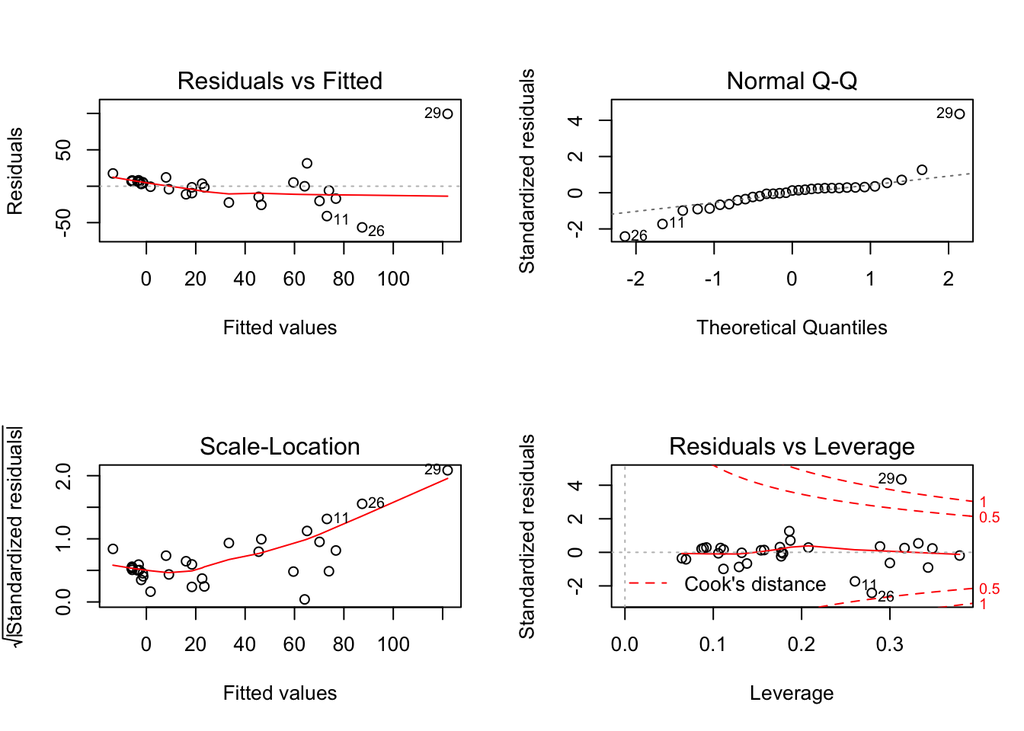

```r
par(mfrow=c(2,2))
plot(res)
```

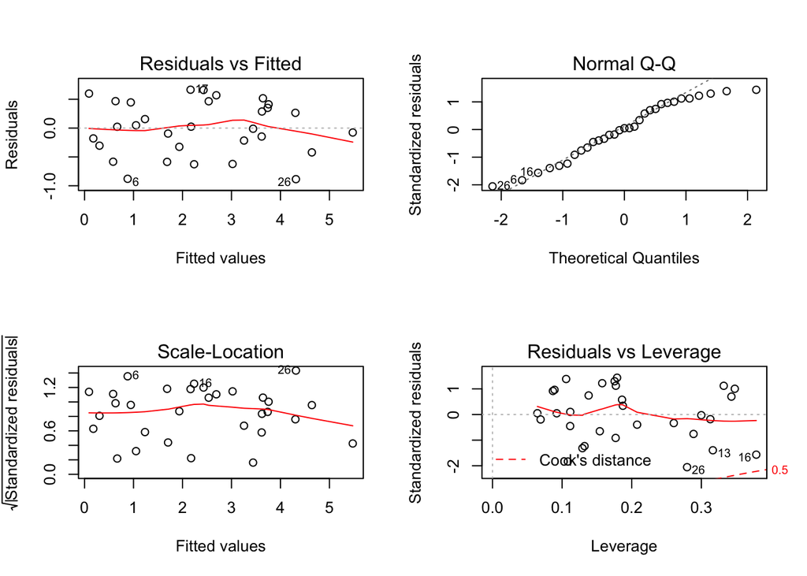

```r
res = lm(log(RC) ~ .,data)
par(mfrow=c(2,2))
plot(res)
```

```r
shapiro.test(res$residuals)
```

```
##
##  Shapiro-Wilk normality test
##
## data:  res$residuals
## W = 0.94891, p-value = 0.1456
```

HO résidus gaussien, H1 pas gaussiens , on garde H0! Ils semblent gaussiens

## Question 6

Or on peut lire les $\hat{\theta}$ sur la colonne `estimate` dans le retour de la commande suivante :

```r
summary(res)
```

```
##
## Call:
## lm(formula = log(RC) ~ ., data = data)
##
## Residuals:
##      Min       1Q   Median       3Q      Max
## -0.88585 -0.31491  0.02299  0.42904  0.66576
##
## Coefficients:
##               Estimate Std. Error t value Pr(>|t|)
## (Intercept) -0.4289010  0.4088689  -1.049   0.3042
## LT           0.0135824  0.0079403   1.711   0.0995 .
## HF           0.0032342  0.0021021   1.539   0.1365
## PR           0.0028888  0.0005816   4.967 4.06e-05 ***
## PA          -0.0002853  0.0001354  -2.107   0.0453 *
## FE          -0.0547214  0.0738678  -0.741   0.4657
## ---
## Signif. codes:  0 '***' 0.001 '**' 0.01 '*' 0.05 '.' 0.1 ' ' 1
##
## Residual standard error: 0.508 on 25 degrees of freedom
## Multiple R-squared:   0.91,  Adjusted R-squared:  0.892
## F-statistic: 50.54 on 5 and 25 DF,  p-value: 2.861e-12
```

On obtien les $\beta_{k}$.

## Question 7

1. Modèle associé aux hypothèses :

Sous $H{0}$ on a : $Y_{i} = \mu + \epsilon_{i}$ Sous $H{1}$ on a : $Y_{i} = \mu + \beta_{1} X_{1i} + \beta_{2} X_{2i}+ \beta_{3} X_{3i}+ \beta_{4} X_{4i}+ \beta_{5} X_{5i} +\epsilon_{i}$

2. Modèle sous $H_{0}$

Y = X_0teta0 $+\epsilon$

DIM M0 = 1 Ychap M0 = XO theta chap 0

or theta chapeau0 = mu chapeau = moyenne = Y barre

SCR = || Y - Ychap||

3. Modèle sous $H_{1}$

Mise sous forme matricielles

Dim = rang(X) = 6 (colonnes indépendantes vérifiée avec le vif)

$(\hat{Y_{M1}})_{i} =(X\hat{\theta})_{i}= \mu + \beta_{1} X_{1i} + \beta_{2} X_{2i}+ \beta_{3} X_{3i}+ \beta_{4} X_{4i}+ \beta_{5} X_{5i} +\epsilon_{i}$

4. test 5%

Student ou fisher? Plusieurs donc fisher (pleins de paramètres nuls à la fois) Stat de test dans le cours, voir dans R ou on l’obtient (Fstatistique)

Stat: somme des carré résiduels etc

Fstatistique : 50.54 on 5 et 25 pvalue = 10^-12 < 5% F obs dim(M1)-dim(MO) n - dim(M1) Au moins une des variables explicatives est significatives

## Question8

On effectue le test de `student`

H0 : B1 = 0 ? H1 : B1 != 0

On cherche T qui suit une student, on regarde ensuite les variables qui sont significatives

Tout est donné dans summary de res. Colonne p-value pour chacune des variable, regarder ou la p-value est < 5%. Pour LT (p-value), pas rejet de H0, LT semble non significative (x1 = 0) pour expliquer Y. Pour HF et FE on a pareil. Mais pour PR et PA on rejette l’hypothèse H0 et on affirme avec un risque 5% que PR et PA sont significatifs pour expliquer Y, les autres ne le sont pas. (semblent pas)

confint(res) plein d’IC 0 dedans?

## Question 9

PR et PA significative, on veut savoir dans quel sens, si PR augment Y augmente? H0 : B3 = 0 H1 : B3 > 0 (estimate est positif donc on le fait dans ce sens là)

T-obs = 4.96 ici. Soit on calcul le quantil, soit on p-value : on divise par 2 la p-value bilatérale (*0.5) (colonne des p-value) Ne pas oublier la transformation. On affirme que elle influe positivement sur log RC.

## Question 10

De m^me sauf que on test si B4<0 car l’estimate est négatif

## Question 11

Dans le res = lm(log(RH) ~ PR+LT,data) et on étudie la stats comme dans les questions précédentes.

```r
res4 = lm(log(RC) ~ PR+LT,data)
anova(res4,res)
```

```
## Analysis of Variance Table
##
## Model 1: log(RC) ~ PR + LT
## Model 2: log(RC) ~ LT + HF + PR + PA + FE
##   Res.Df    RSS Df Sum of Sq      F  Pr(>F)
## 1     28 9.1378
## 2     25 6.4521  3    2.6857 3.4688 0.03112 *
## ---
## Signif. codes:  0 '***' 0.001 '**' 0.01 '*' 0.05 '.' 0.1 ' ' 1
```

Interprétation : preves pour accepter le gros modèle? Si oui alors on le garde mais sinon on le garde pas

A mettre sous forme matricielle $H_{0} : (\hat{Y_{M1}})_{i} =(X\hat{\theta})_{i}= \mu + \beta_{1} X_{1i} + \beta_{3} X_{3i} +\epsilon_{i}$ dim =3

$H_{1} : (\hat{Y_{M1}})_{i} =(X\hat{\theta})_{i}= \mu + \beta_{1} X_{1i} + \beta_{2} X_{2i}+ \beta_{3} X_{3i}+ \beta_{4} X_{4i}+ \beta_{5} X_{5i} +\epsilon_{i}$ dim = 6

On utilise la stat de Fisher

On rejette H0 à risque de se tromper 5%!

## Question 12

```r
res4 = lm(log(RC) ~ PR+PA,data)
anova(res4,res)
```

```
## Analysis of Variance Table
##
## Model 1: log(RC) ~ PR + PA
## Model 2: log(RC) ~ LT + HF + PR + PA + FE
##   Res.Df    RSS Df Sum of Sq      F Pr(>F)
## 1     28 7.6588
## 2     25 6.4521  3    1.2067 1.5586 0.2242
```

On ne rejette pas H0 et on dit que cela semble suffisant comme modèle

# Exercice d’entrainement

Charger Ozone, on va l’explique en fonction de toutes les variables quantitatives

On retire pluie et vent qui sont qualitatives pas quantitatives

```r
#ozone2 = ozone[,-c(1,13,14)]
```